**Jorge A. Martín-Ávila**[Home](https://jamartinavila.github.io/JAMAWeb/)[Research & Fieldwork](https://jamartinavila.github.io/JAMAWeb/Projects.html)[Publications](https://jamartinavila.github.io/JAMAWeb/Publications.html)[BIOS Cabo Verde](https://bioscaboverde.com/)

← Back to Research FIELDWORK JOURNAL · 2018 · BOA VISTA

# Four weeks on the *turtle coast.*

Volunteering with BIOS Cabo Verde on the nesting beaches of Boa Vista: night patrols, sea turtle monitoring, nest protection and the daily work behind field conservation.

**2018**Field season

**4 weeks**Volunteering

**6 km**Beach monitored

*Caretta caretta*Focal species

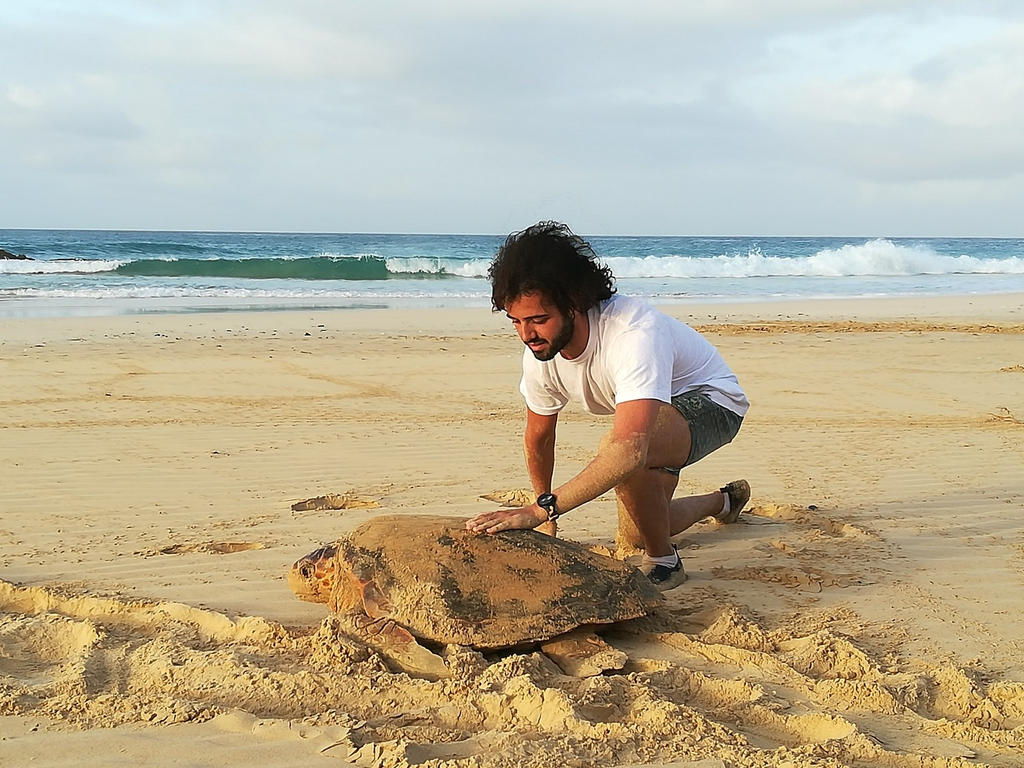

On the nesting beach, Boa Vista · Fieldwork photograph, 2018

WHY BOA VISTA

## Where conservation begins on the sand

Boa Vista is one of the world's most important nesting areas for the loggerhead sea turtle (*Caretta caretta*). Protecting its beaches requires sustained field monitoring and a coordinated effort by conservation staff and volunteers.

THE ORGANISATION

[BIOS Cabo Verde](https://bioscaboverde.com/) is a conservation organisation working on marine and coastal biodiversity through research, monitoring, education and community engagement. Its sea turtle programme includes nesting beach patrols, tagging, nest monitoring and hatchling protection.

[Explore BIOS's sea turtle programme ↗](https://bioscaboverde.com/tartarugas/)

FIELD NOTES · LIFE AT CAMP

## A camp beneath an old acacia.

For four weeks, our home was a field camp on the southern coast of Boa Vista. An enormous old acacia stood at its centre: between its trunks and branches, we built and sheltered tents, cooking areas and shared spaces. Life was simple, communal and organised around the rhythm of the beach.

Beyond the camp lay approximately six kilometres of largely untouched coastline that our team patrolled and helped protect from poaching. Once night fell, the beach became our workplace.

FIRST SHIFT**20:00–02:00**Night patrol & monitoring

SECOND SHIFT**02:00–10:00**Late-night & morning fieldwork

WHAT I DID

## From tracks to data.

These are the tasks I personally carried out as a conservation volunteer in 2018 — distinct from the broader research programme run by BIOS Cabo Verde.

01 / BEACH PATROLS

### Following the nesting tracks

Patrolled beaches at night to locate nesting females and nesting activity, helped protect the monitored coastline, and carried out turtle censuses by counting tracks left in the sand.

02 / ADULT TURTLES

### Marking and measuring

Assisted with the marking and morphometric measurement of nesting sea turtles and recorded field observations, including counts of eggs in clutches.

03 / NESTS & HATCHLINGS

### Protecting the next generation

Located, monitored and protected nests; helped relocate clutches to a protected hatchery when needed; and collected and measured hatchlings as part of the monitoring work.

04 / DATA & OUTREACH

### Beyond the night patrol

Collected scientific field data, organised and cleaned monitoring databases, and contributed to environmental education activities connected with sea turtle conservation.

A PERSONAL FIELD EXPERIENCE

## Behind each night on the beach

Conservation fieldwork is built on many small, repeated tasks: walking the same stretch of sand, reading tracks, checking nests, recording measurements carefully and returning to camp to make sure the data are usable.

Working alongside the BIOS team brought together direct contact with wildlife, collective responsibility for a vulnerable nesting coastline, and the less visible but essential work of organising ecological information.

Four weeks of hands-on conservation — from the beach to the database.

2018 · PHOTO JOURNAL

## The field season, in pictures.

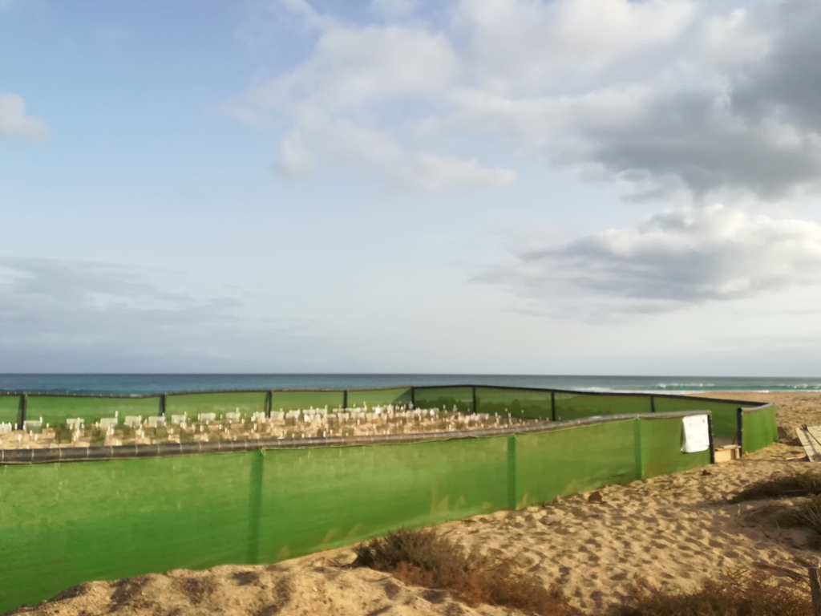

01 · NEST CONSERVATION**A safer place for vulnerable nests.** Behind the green mesh of the hatchery, relocated clutches could be incubated under protected conditions. Part of our work involved transferring nests at risk, following their development and collecting information on hatchlings.

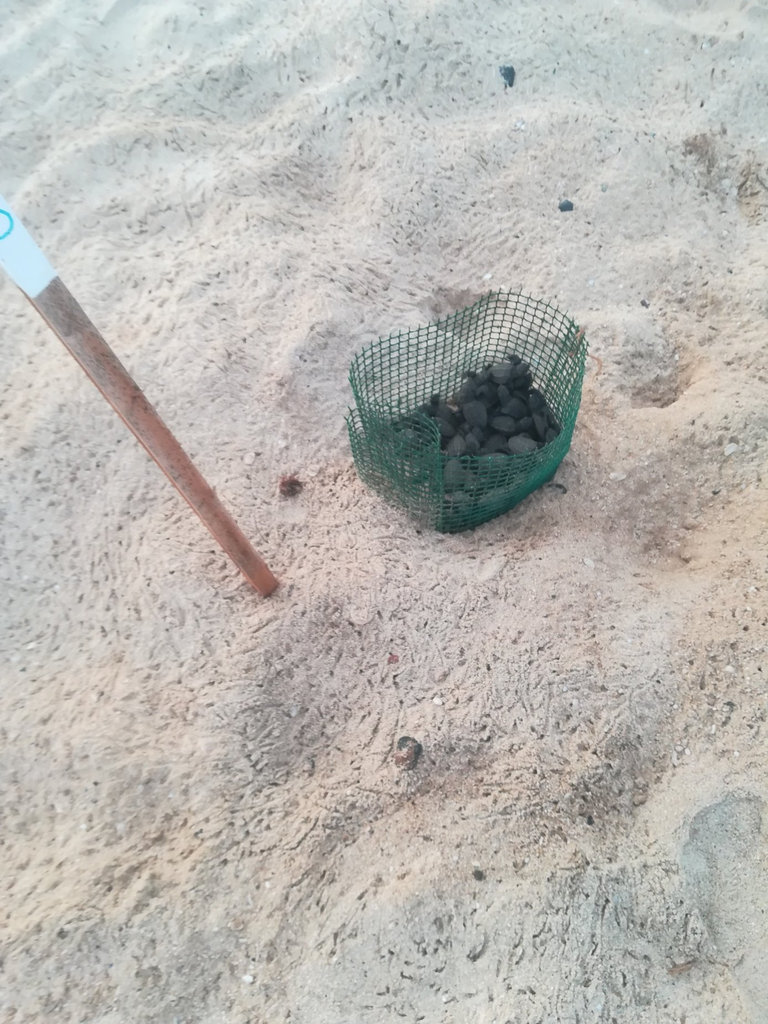

02 · HATCHLINGS**A basketful of new beginnings.** Hatchlings gathered for monitoring on the sand. These close encounters were part of careful field routines that turned individual observations into conservation records.

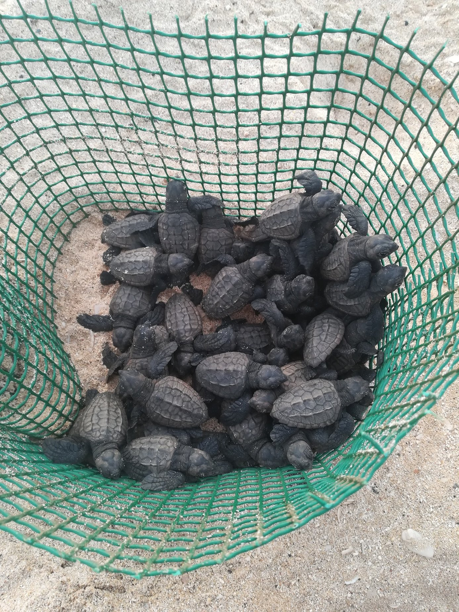

03 · CLOSE-UP**Life on a miniature scale.** A closer view of the hatchlings, each only a fraction of the size of the nesting females we encountered during patrols.

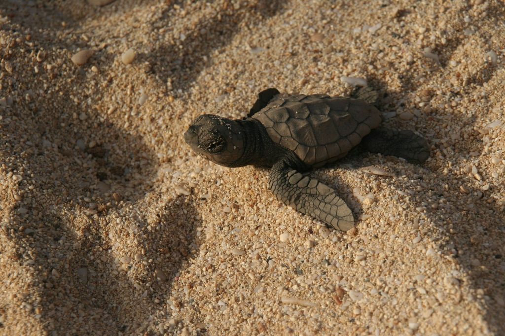

04 · A NEW GENERATION**The smallest protagonists.** A newly emerged loggerhead on the sand — a reminder of why protecting nesting habitat matters.

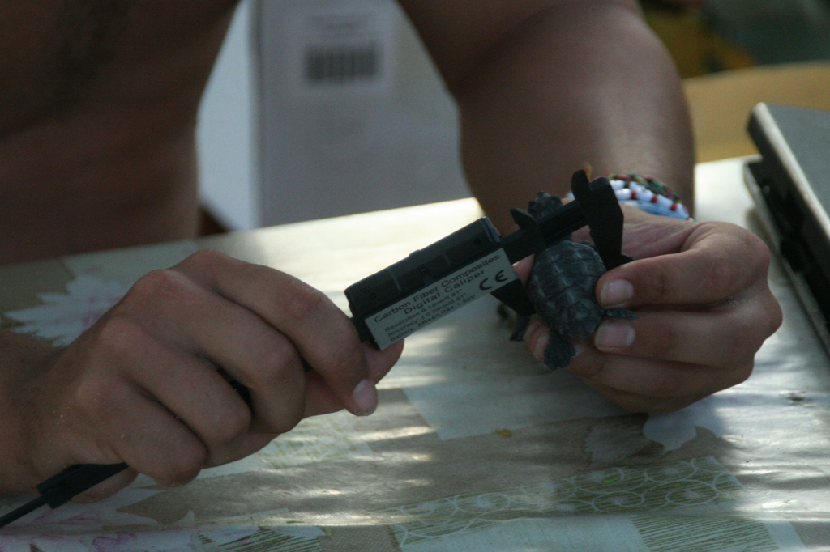

05 · FIELD METHODS**Measurements that matter.** Morphometric measurements of hatchlings were one of the practical tasks we carried out, together with careful data recording and database cleaning.

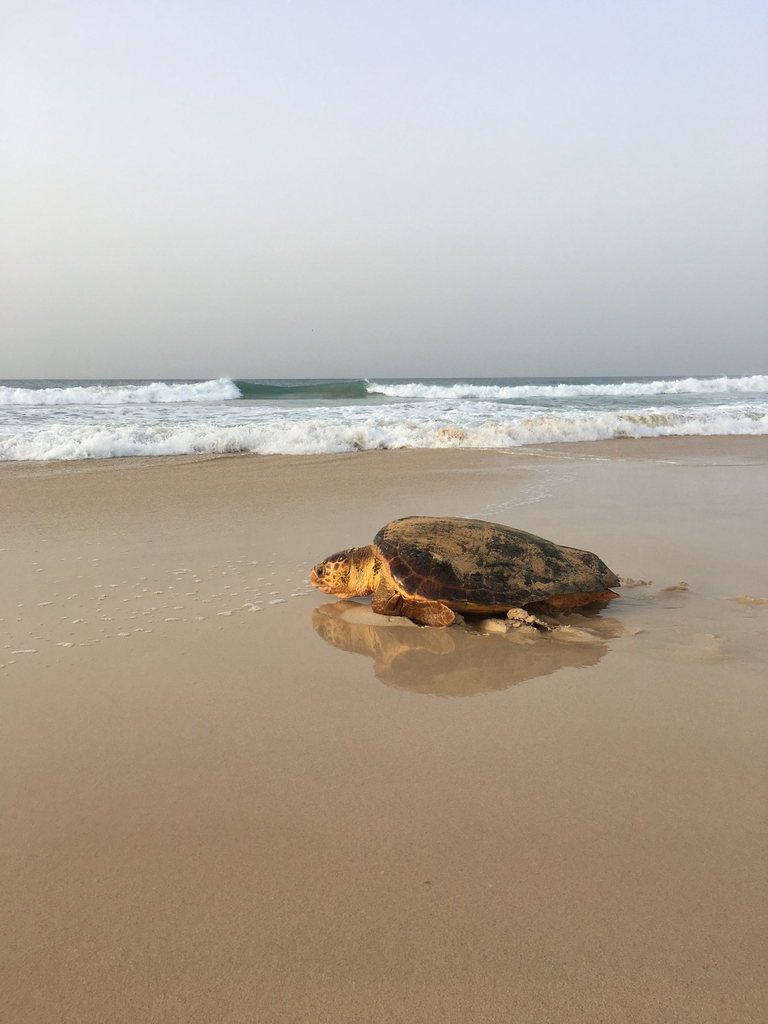

06 · THE NESTING COAST**Between sand and sea.** An adult loggerhead against the Atlantic surf. On Boa Vista, the meeting point between ocean and beach is also a critical place for the next generation.

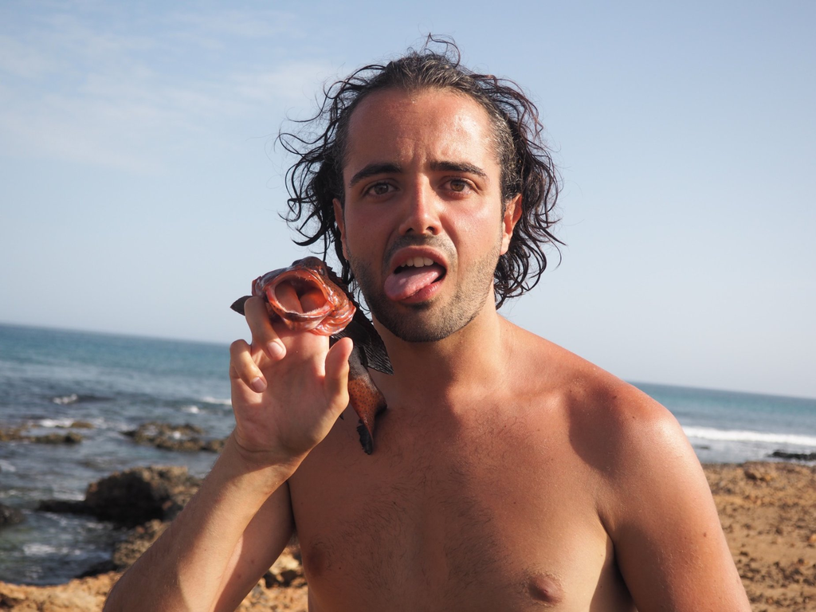

07 · BEYOND THE PATROLS**Life between shifts.** Not every memory was a field sheet. The people, the sea and the shared moments between patrols became part of the experience too.

All photographs from my 2018 stay with BIOS Cabo Verde. The captions are personal reflections on my volunteer experience, not claims of research leadership or measured project outcomes.

CREDIT & CONTEXT

## Conservation is a team effort.

This page describes my four-week **volunteer field experience in 2018**, not leadership of a BIOS research project. The monitoring and conservation programme is developed by BIOS Cabo Verde and its team, with the contribution of many local and international volunteers.

[Discover BIOS Cabo Verde ↗](https://bioscaboverde.com/)